# GO Semantic Similarity

Erin Chille

Last updated 2020/11/03

Prepare workspace

```r
rm(list=ls()) # removes all prior objects
library(tidyverse)
library(org.Hs.eg.db)
library(simplifyEnrichment)
library(magick)
```

#Maternal

Load GO data and select only the GO_IDs associated with BP terms

```r
MatGO <- read_csv("2a-WGCNA/Output/GO.05.Mat.csv", col_names = TRUE)
nrow(MatGO) # total #enriched terms
```

```
## [1] 216
```

```r
nrow(filter(MatGO, ontology=="BP")) #BP terms
```

```
## [1] 92
```

```r
nrow(filter(MatGO, ontology=="CC")) #CC terms
```

```
## [1] 32
```

```r
nrow(filter(MatGO, ontology=="MF")) #MF terms
```

```
## [1] 92
```

```r
MatGO.BP <- MatGO %>% filter(ontology == "BP")
MatBP <- MatGO.BP$category
MatGO.MF <- MatGO %>% filter(ontology == "MF")
MatMF <- MatGO.MF$category
```

Calculate a similarity matrix and save the output.

```r
Mat = GO_similarity(MatBP, ont = "BP", db = "org.Hs.eg.db")
pdf(file = "3-Semantic-Similarity/Output/Biological_Process_Plots/MatBP_GOSEM.pdf", width = 7, height = 5)
simplifyGO(Mat, word_cloud_grob_param = list(max_width = 50), max_words=20)
```

```
## Cluster 92 terms by 'binary_cut'... 10 clusters, used 0.1820681 secs.
```

```r
dev.off()
```

```r
pdf(file = "3-Semantic-Similarity/Output/Molecular_Function_Plots/MatMF_GOSEM.pdf", width = 7, height = 5)
Mat = GO_similarity(MatMF, ont = "MF", db = "org.Hs.eg.db")
simplifyGO(Mat, word_cloud_grob_param = list(max_width = 50), max_words=20)
```

```
## Cluster 92 terms by 'binary_cut'... 11 clusters, used 0.2110231 secs.
```

```r
dev.off()
```

Load GO data and select only the GO_IDs associated with BP terms

```r
UEGO <- read_csv("2a-WGCNA/Output/GO.05.UE.csv", col_names = TRUE)
nrow(UEGO) # total #enriched terms
```

```
## [1] 202
```

```r
nrow(filter(UEGO, ontology=="BP")) #BP terms
```

```
## [1] 83
```

```r
nrow(filter(UEGO, ontology=="CC")) #CC terms
```

```
## [1] 29
```

```r
nrow(filter(UEGO, ontology=="MF")) #MF terms
```

```
## [1] 90
```

```r
UEGO.BP <- UEGO %>% filter(ontology == "BP")
UEBP <- UEGO.BP$category
# UEGO.MF <- UEGO %>% filter(ontology == "MF")
# UEMF <- UEGO.MF$category
```

Calculate a similarity matrix and save the output.

```r
UE = GO_similarity(UEBP, ont = "BP", db = "org.Hs.eg.db")
pdf(file = "3-Semantic-Similarity/Output/Biological_Process_Plots/UEBP_GOSEM.pdf", width = 7, height = 5)
simplifyGO(UE, word_cloud_grob_param = list(max_width = 50), max_words=20)
```

```
## Cluster 83 terms by 'binary_cut'... 8 clusters, used 0.1368229 secs.
```

```r
dev.off()
```

```r
# UE = GO_similarity(UEMF, ont = "MF", db = "org.Hs.eg.db")
# simplifyGO(UE, word_cloud_grob_param = list(max_width = 50), max_words=20)
```

Load GO data and select only the GO_IDs associated with BP terms

```r
FEGO <- read_csv("2a-WGCNA/Output/GO.05.FE.csv", col_names = TRUE)
nrow(FEGO) # total #enriched terms
```

```
## [1] 153
```

```r
nrow(filter(FEGO, ontology=="BP")) #BP terms
```

```
## [1] 68
```

```r
nrow(filter(FEGO, ontology=="CC")) #CC terms
```

```
## [1] 23
```

```r
nrow(filter(FEGO, ontology=="MF")) #MF terms
```

```
## [1] 62
```

```r
FEGO.BP <- FEGO %>% filter(ontology == "BP")
FEBP <- FEGO.BP$category
# FEGO.MF <- FEGO %>% filter(ontology == "MF")
# FEMF <- FEGO.MF$category
```

Calculate a similarity matrix and save the output.

```r
FE = GO_similarity(FEBP, ont = "BP", db = "org.Hs.eg.db")
pdf(file = "3-Semantic-Similarity/Output/Biological_Process_Plots/FEBP_GOSEM.pdf", width = 7, height = 5)
simplifyGO(FE, word_cloud_grob_param = list(max_width = 50), max_words=20)
```

```
## Cluster 68 terms by 'binary_cut'... 7 clusters, used 0.107486 secs.
```

```r
dev.off()
```

```r
# FE = GO_similarity(FEMF, ont = "MF", db = "org.Hs.eg.db")
# simplifyGO(FE, word_cloud_grob_param = list(max_width = 50), max_words=20)
```

# First ZGA

Load GO data and select only the GO_IDs associated with BP terms

```r
ZGA1GO <- read_csv("2a-WGCNA/Output/GO.05.ZGA1.csv", col_names = TRUE)
nrow(ZGA1GO) # total #enriched terms
```

```
## [1] 136
```

```r
nrow(filter(ZGA1GO, ontology=="BP")) #BP terms
```

```
## [1] 55
```

```r
nrow(filter(ZGA1GO, ontology=="CC")) #CC terms
```

```
## [1] 21
```

```r
nrow(filter(ZGA1GO, ontology=="MF")) #MF terms
```

```
## [1] 60
```

```r
ZGA1GO.BP <- ZGA1GO %>% filter(ontology == "BP")
ZGA1BP <- ZGA1GO.BP$category
ZGA1GO.MF <- ZGA1GO %>% filter(ontology == "MF")
ZGA1MF <- ZGA1GO.MF$category
```

Calculate a similarity matrix and save the output.

```r
ZGA1 = GO_similarity(ZGA1BP, ont = "BP", db = "org.Hs.eg.db")
pdf(file = "3-Semantic-Similarity/Output/Biological_Process_Plots/ZGA1_GOSEM.pdf", width = 7, height = 5)
simplifyGO(ZGA1, word_cloud_grob_param = list(max_width = 50), max_words=20)
```

```
## Cluster 55 terms by 'binary_cut'... 5 clusters, used 0.08638906 secs.
```

```r
dev.off()
```

```r
pdf(file = "3-Semantic-Similarity/Output/Molecular_Function_Plots/ZGA1MF_GOSEM.pdf", width = 7, height = 5)
ZGA1 = GO_similarity(ZGA1MF, ont = "MF", db = "org.Hs.eg.db")
simplifyGO(ZGA1, word_cloud_grob_param = list(max_width = 50), max_words=20)
```

```
## Cluster 60 terms by 'binary_cut'... 11 clusters, used 0.203418 secs.
```

```r
dev.off()
```

Load GO data and select only the GO_IDs associated with BP terms

```r
ClvgGO <- read_csv("2a-WGCNA/Output/GO.05.Clvg.csv", col_names = TRUE)
nrow(ClvgGO) # total #enriched terms
```

```
## [1] 106
```

```r
nrow(filter(ClvgGO, ontology=="BP")) #BP terms
```

```
## [1] 45
```

```r
nrow(filter(ClvgGO, ontology=="CC")) #CC terms
```

```
## [1] 11
```

```r
nrow(filter(ClvgGO, ontology=="MF")) #MF terms
```

```
## [1] 50
```

```r
ClvgGO.BP <- ClvgGO %>% filter(ontology == "BP")
ClvgBP <- ClvgGO.BP$category
# ClvgGO.MF <- ClvgGO %>% filter(ontology == "MF")
# ClvgMF <- ClvgGO.MF$category
```

Calculate a similarity matrix and save the output.

```r
Clvg = GO_similarity(ClvgBP, ont = "BP", db = "org.Hs.eg.db")
pdf(file = "3-Semantic-Similarity/Output/Biological_Process_Plots/ClvgBP_GOSEM.pdf", width = 7, height = 5)
simplifyGO(Clvg, word_cloud_grob_param = list(max_width = 50), max_words=20)
```

```
## Cluster 45 terms by 'binary_cut'... 6 clusters, used 0.06782317 secs.
```

```r
dev.off()
```

```r
# Clvg = GO_similarity(ClvgMF, ont = "MF", db = "org.Hs.eg.db")
# simplifyGO(Clvg, word_cloud_grob_param = list(max_width = 50), max_words=20)
```

Load GO data and select only the GO_IDs associated with BP terms

```r
PCGO <- read_csv("2a-WGCNA/Output/GO.05.PC.csv", col_names = TRUE)
nrow(PCGO) # total #enriched terms
```

```
## [1] 114
```

```r
nrow(filter(PCGO, ontology=="BP")) #BP terms
```

```
## [1] 52
```

```r
nrow(filter(PCGO, ontology=="CC")) #CC terms
```

```
## [1] 11
```

```r
nrow(filter(PCGO, ontology=="MF")) #MF terms
```

```
## [1] 51
```

```r
PCGO.BP <- PCGO %>% filter(ontology == "BP")
PCBP <- PCGO.BP$category
# PCGO.MF <- PCGO %>% filter(ontology == "MF")
# PCMF <- PCGO.MF$category
```

Calculate a similarity matrix and save the output.

```r
PC = GO_similarity(PCBP, ont = "BP", db = "org.Hs.eg.db")
pdf(file = "3-Semantic-Similarity/Output/Biological_Process_Plots/PCBP_GOSEM.pdf", width = 7, height = 5)
simplifyGO(PC, word_cloud_grob_param = list(max_width = 50), max_words=20)
```

```
## Cluster 52 terms by 'binary_cut'... 5 clusters, used 0.1107731 secs.
```

```r
dev.off()
```

```r
# PC = GO_similarity(PCMF, ont = "MF", db = "org.Hs.eg.db")
# simplifyGO(PC, word_cloud_grob_param = list(max_width = 50), max_words=20)
```

Load GO data and select only the GO_IDs associated with BP terms

```r
EGGO <- read_csv("2a-WGCNA/Output/GO.05.EG.csv", col_names = TRUE)
nrow(EGGO) # total #enriched terms
```

```
## [1] 113
```

```r
nrow(filter(EGGO, ontology=="BP")) #BP terms
```

```
## [1] 48
```

```r
nrow(filter(EGGO, ontology=="CC")) #CC terms
```

```
## [1] 19
```

```r
nrow(filter(EGGO, ontology=="MF")) #MF terms
```

```
## [1] 46
```

```r
EGGO.BP <- EGGO %>% filter(ontology == "BP")
EGBP <- EGGO.BP$category
# EGGO.MF <- EGGO %>% filter(ontology == "MF")
# EGMF <- EGGO.MF$category
```

Calculate a similarity matrix and save the output.

```r
EG = GO_similarity(EGBP, ont = "BP", db = "org.Hs.eg.db")
pdf(file = "3-Semantic-Similarity/Output/Biological_Process_Plots/EGBP_GOSEM.pdf", width = 7, height = 5)
simplifyGO(EG, word_cloud_grob_param = list(max_width = 50), max_words=20)
```

```
## Cluster 48 terms by 'binary_cut'... 9 clusters, used 0.107178 secs.
```

```r
dev.off()
```

```r
# EG = GO_similarity(EGMF, ont = "MF", db = "org.Hs.eg.db")
# simplifyGO(EG, word_cloud_grob_param = list(max_width = 50), max_words=20)
```

#Second ZGA

Load GO data and select only the GO_IDs associated with BP terms

```r
ZGA2GO <- read_csv("2a-WGCNA/Output/GO.05.ZGA2.csv", col_names = TRUE)
nrow(ZGA2GO) # total #enriched terms
```

```
## [1] 85
```

```r
nrow(filter(ZGA2GO, ontology=="BP")) #BP terms
```

```
## [1] 22
```

```r
nrow(filter(ZGA2GO, ontology=="CC")) #CC terms
```

```
## [1] 15
```

```r
nrow(filter(ZGA2GO, ontology=="MF")) #MF terms
```

```
## [1] 47
```

```r
ZGA2GO.BP <- ZGA2GO %>% filter(ontology == "BP")
ZGA2BP <- ZGA2GO.BP$category
ZGA2GO.MF <- ZGA2GO %>% filter(ontology == "MF")
ZGA2MF <- ZGA2GO.MF$category
```

Calculate a similarity matrix and save the output.

```r
ZGA2 = GO_similarity(ZGA2BP, ont = "BP", db = "org.Hs.eg.db")
pdf(file = "3-Semantic-Similarity/Output/Biological_Process_Plots/ZGA2BP_GOSEM.pdf", width = 7, height = 5)
simplifyGO(ZGA2, word_cloud_grob_param = list(max_width = 50), max_words=20)
```

```
## Cluster 22 terms by 'binary_cut'... 4 clusters, used 0.03258204 secs.
```

```r
dev.off()
```

```r
pdf(file = "3-Semantic-Similarity/Output/Molecular_Function_Plots/ZGA2MF_GOSEM.pdf", width = 7, height = 5)
ZGA2 = GO_similarity(ZGA2MF, ont = "MF", db = "org.Hs.eg.db")
simplifyGO(ZGA2, word_cloud_grob_param = list(max_width = 50), max_words=20)
```

```
## Cluster 47 terms by 'binary_cut'... 12 clusters, used 0.1189291 secs.
```

```r
dev.off()
```

Load GO data and select only the GO_IDs associated with BP terms

```r
MGGO <- read_csv("2a-WGCNA/Output/GO.05.MG.csv", col_names = TRUE)
nrow(MGGO) # total #enriched terms
```

```
## [1] 140
```

```r
nrow(filter(MGGO, ontology=="BP")) #BP terms
```

```
## [1] 65
```

```r
nrow(filter(MGGO, ontology=="CC")) #CC terms
```

```
## [1] 25
```

```r
nrow(filter(MGGO, ontology=="MF")) #MF terms
```

```
## [1] 50
```

```r
MGGO.BP <- MGGO %>% filter(ontology == "BP")
MGBP <- MGGO.BP$category
# MGGO.MF <- MGGO %>% filter(ontology == "MF")
# MGMF <- MGGO.MF$category
```

Calculate a similarity matrix and save the output.

```r
MG = GO_similarity(MGBP, ont = "BP", db = "org.Hs.eg.db")
pdf(file = "3-Semantic-Similarity/Output/Biological_Process_Plots/MGBP_GOSEM.pdf", width = 7, height = 5)
simplifyGO(MG, word_cloud_grob_param = list(max_width = 50), max_words=20)
```

```
## Cluster 65 terms by 'binary_cut'... 10 clusters, used 0.1062272 secs.
```

```r
dev.off()
```

```r
# MG = GO_similarity(MGMF, ont = "MF", db = "org.Hs.eg.db")
# simplifyGO(MG, word_cloud_grob_param = list(max_width = 50), max_words=20)
```

Load GO data and select only the GO_IDs associated with BP terms

```r
LGGO <- read_csv("2a-WGCNA/Output/GO.05.LG.csv", col_names = TRUE)
nrow(LGGO) # total #enriched terms
```

```
## [1] 85
```

```r
nrow(filter(LGGO, ontology=="BP")) #BP terms
```

```
## [1] 34
```

```r
nrow(filter(LGGO, ontology=="CC")) #CC terms
```

```
## [1] 12
```

```r
nrow(filter(LGGO, ontology=="MF")) #MF terms
```

```
## [1] 39
```

```r
LGGO.BP <- LGGO %>% filter(ontology == "BP")
LGBP <- LGGO.BP$category
# LGGO.MF <- LGGO %>% filter(ontology == "MF")
# LGMF <- LGGO.MF$category
```

Calculate a similarity matrix and save the output.

```r
LG = GO_similarity(LGBP, ont = "BP", db = "org.Hs.eg.db")
pdf(file = "3-Semantic-Similarity/Output/Biological_Process_Plots/LGBP_GOSEM.pdf", width = 7, height = 5)
simplifyGO(LG, word_cloud_grob_param = list(max_width = 50), max_words=20)
```

```
## Cluster 34 terms by 'binary_cut'... 6 clusters, used 0.05532789 secs.
```

```r
dev.off()
```

```r
# LG = GO_similarity(LGMF, ont = "MF", db = "org.Hs.eg.db")
# simplifyGO(LG, word_cloud_grob_param = list(max_width = 50), max_words=20)
```

Load GO data and select only the GO_IDs associated with BP terms

```r
PlnGO <- read_csv("2a-WGCNA/Output/GO.05.Pln.csv", col_names = TRUE)
nrow(PlnGO) # total #enriched terms
```

```
## [1] 87
```

```r
nrow(filter(PlnGO, ontology=="BP")) #BP terms
```

```
## [1] 24
```

```r
nrow(filter(PlnGO, ontology=="CC")) #CC terms
```

```
## [1] 14
```

```r
nrow(filter(PlnGO, ontology=="MF")) #MF terms
```

```
## [1] 48
```

```r
PlnGO.BP <- PlnGO %>% filter(ontology == "BP")
PlnBP <- PlnGO.BP$category
# PlnGO.MF <- PlnGO %>% filter(ontology == "MF")
# PlnMF <- PlnGO.MF$category
```

Calculate a similarity matrix and save the output.

```r
Pln = GO_similarity(PlnBP, ont = "BP", db = "org.Hs.eg.db")
pdf(file = "3-Semantic-Similarity/Output/Biological_Process_Plots/PlnBP_GOSEM.pdf", width = 7, height = 5)
simplifyGO(Pln, word_cloud_grob_param = list(max_width = 50), max_words=20)
```

```
## Cluster 24 terms by 'binary_cut'... 4 clusters, used 0.03833699 secs.
```

```r
dev.off()
```

```r
# Pln = GO_similarity(PlnMF, ont = "MF", db = "org.Hs.eg.db")
# simplifyGO(Pln, word_cloud_grob_param = list(max_width = 50), max_words=20)
```

#Adult

Load GO data and select only the GO_IDs associated with BP terms

```r
AdultGO <- read_csv("2a-WGCNA/Output/GO.05.Adult.csv", col_names = TRUE)
nrow(AdultGO) # total #enriched terms
```

```
## [1] 93
```

```r
nrow(filter(AdultGO, ontology=="BP")) #BP terms
```

```
## [1] 31
```

```r
nrow(filter(AdultGO, ontology=="CC")) #CC terms
```

```
## [1] 7
```

```r
nrow(filter(AdultGO, ontology=="MF")) #MF terms
```

```
## [1] 54
```

```r
AdultGO.BP <- AdultGO %>% filter(ontology == "BP")
AdultBP <- AdultGO.BP$category
AdultGO.MF <- AdultGO %>% filter(ontology == "MF")
AdultMF <- AdultGO.MF$category
```

Calculate a similarity matrix and save the output.

```r
pdf(file = "3-Semantic-Similarity/Output/Biological_Process_Plots/AdultBP_GOSEM.pdf", width = 7, height = 5)
Adult = GO_similarity(AdultBP, ont = "BP", db = "org.Hs.eg.db")
simplifyGO(Adult, word_cloud_grob_param = list(max_width = 50), max_words=20)
```

```
## Cluster 31 terms by 'binary_cut'... 6 clusters, used 0.04718399 secs.
```

```r
dev.off()
```

```r
pdf(file = "3-Semantic-Similarity/Output/Molecular_Function_Plots/AdultMF_GOSEM.pdf", width = 7, height = 5)
Adult = GO_similarity(AdultMF, ont = "MF", db = "org.Hs.eg.db")
simplifyGO(Adult, word_cloud_grob_param = list(max_width = 50), max_words=20)
```

```
## Cluster 54 terms by 'binary_cut'... 8 clusters, used 0.08839178 secs.
```

```r
dev.off()
```

#Create bar plots of each life stage

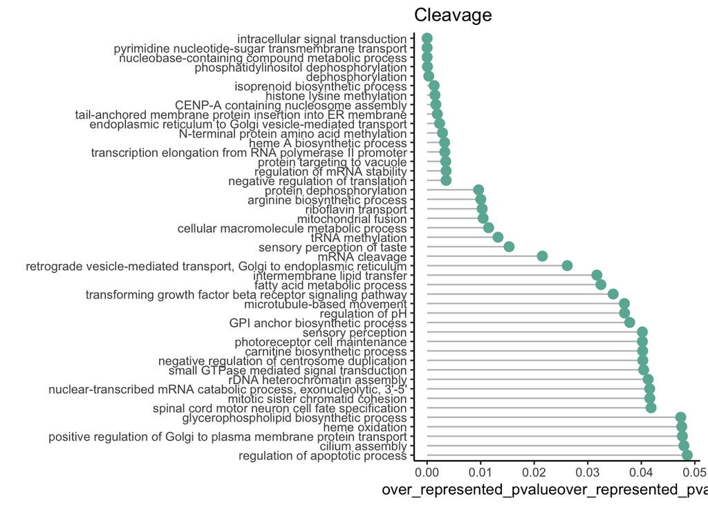

```r
ClvgGO.BP %>%
  mutate(term = fct_reorder(term, over_represented_pvalue, .desc = TRUE)) %>%
  ggplot(aes(x=term, y=over_represented_pvalue) ) +
      geom_segment( aes(x=term ,xend=term, y=0, yend=over_represented_pvalue), color="grey") +
      geom_point(size=3, color="#69b3a2") +
      coord_flip() +
      theme(
        panel.grid.minor.y = element_blank(),
        panel.grid.major.y = element_blank(),
        legend.position="none"
      ) +
  xlab("") +
  ylab("over_represented_pvalueover_represented_pvalue") +
  ggtitle("Cleavage") + #add a main title
  theme(plot.title = element_text(face = 'bold',
                                  size = 12,
                                  hjust = 0)) +
  theme_bw() + #Set background color
  theme(panel.border = element_blank(), # Set border
                     panel.grid.major = element_blank(), #Set major gridlines
                     panel.grid.minor = element_blank(), #Set minor gridlines
                     axis.line = element_line(colour = "black"), #Set axes color
        plot.background=element_blank(),#Set the plot background
        legend.position="none")
```

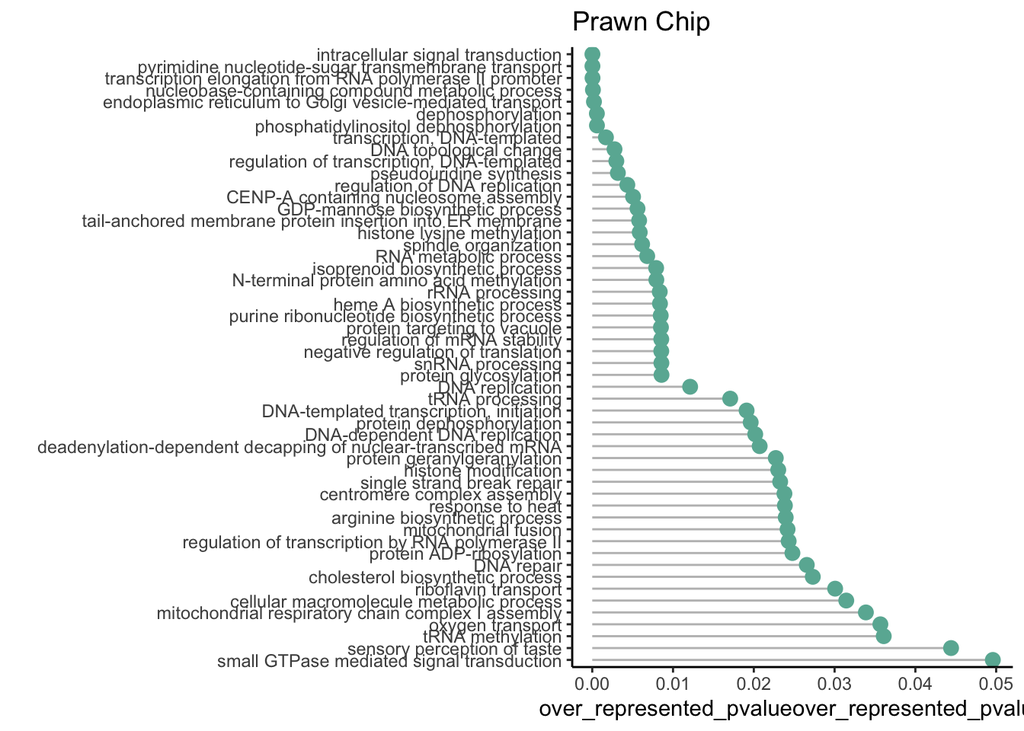

```r
PCGO.BP %>%
  mutate(term = fct_reorder(term, over_represented_pvalue, .desc = TRUE)) %>%
  ggplot(aes(x=term, y=over_represented_pvalue) ) +
      geom_segment( aes(x=term ,xend=term, y=0, yend=over_represented_pvalue), color="grey") +
      geom_point(size=3, color="#69b3a2") +
      coord_flip() +
      theme(
        panel.grid.minor.y = element_blank(),
        panel.grid.major.y = element_blank(),
        legend.position="none"
      ) +
  xlab("") +
  ylab("over_represented_pvalueover_represented_pvalue") +
  ggtitle("Prawn Chip") + #add a main title
  theme(plot.title = element_text(face = 'bold',
                                  size = 12,
                                  hjust = 0)) +
  theme_bw() + #Set background color
  theme(panel.border = element_blank(), # Set border
                     panel.grid.major = element_blank(), #Set major gridlines
                     panel.grid.minor = element_blank(), #Set minor gridlines
                     axis.line = element_line(colour = "black"), #Set axes color
        plot.background=element_blank(),#Set the plot background
        legend.position="none")
```

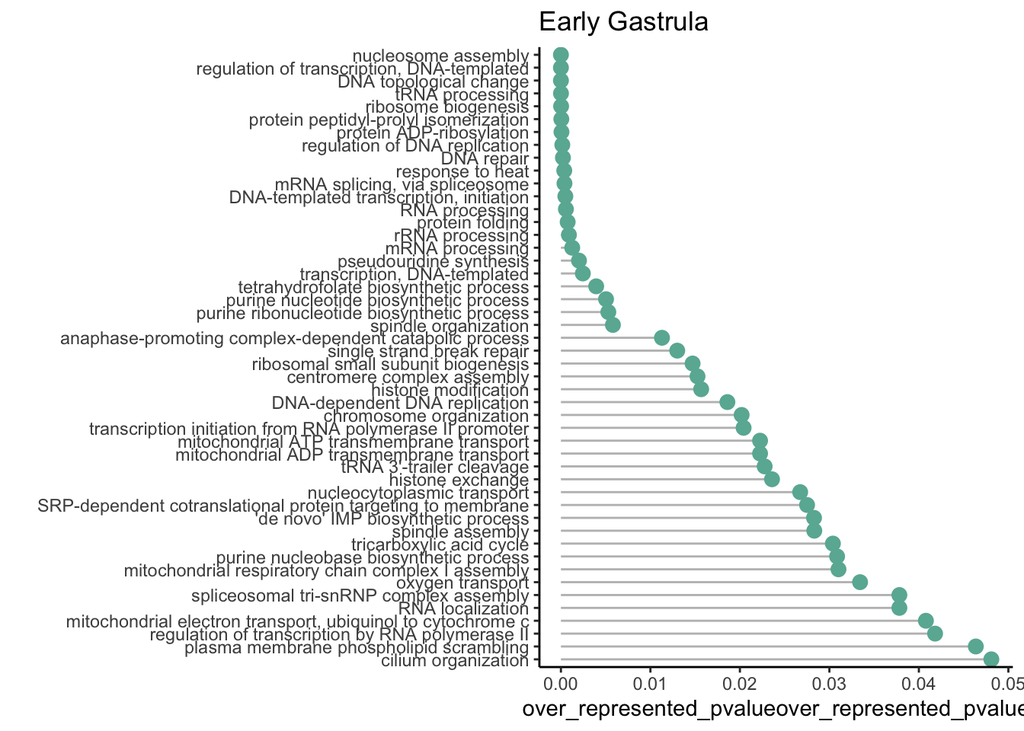

```r
EGGO.BP %>%
  mutate(term = fct_reorder(term, over_represented_pvalue, .desc = TRUE)) %>%
  ggplot(aes(x=term, y=over_represented_pvalue) ) +
      geom_segment( aes(x=term ,xend=term, y=0, yend=over_represented_pvalue), color="grey") +
      geom_point(size=3, color="#69b3a2") +
      coord_flip() +
      theme(
        panel.grid.minor.y = element_blank(),
        panel.grid.major.y = element_blank(),
        legend.position="none"
      ) +
  xlab("") +
  ylab("over_represented_pvalueover_represented_pvalue") +
  ggtitle("Early Gastrula") + #add a main title
  theme(plot.title = element_text(face = 'bold',
                                  size = 12,
                                  hjust = 0)) +
  theme_bw() + #Set background color
  theme(panel.border = element_blank(), # Set border
                     panel.grid.major = element_blank(), #Set major gridlines
                     panel.grid.minor = element_blank(), #Set minor gridlines
                     axis.line = element_line(colour = "black"), #Set axes color
        plot.background=element_blank(),#Set the plot background
        legend.position="none")
```

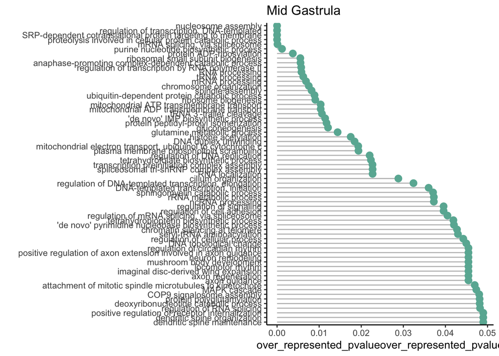

```r
MGGO.BP %>%
  mutate(term = fct_reorder(term, over_represented_pvalue, .desc = TRUE)) %>%
  ggplot(aes(x=term, y=over_represented_pvalue) ) +
      geom_segment( aes(x=term ,xend=term, y=0, yend=over_represented_pvalue), color="grey") +
      geom_point(size=3, color="#69b3a2") +
      coord_flip() +
      theme(
        panel.grid.minor.y = element_blank(),
        panel.grid.major.y = element_blank(),
        legend.position="none"
      ) +
  xlab("") +
  ylab("over_represented_pvalueover_represented_pvalue") +
  ggtitle("Mid Gastrula") + #add a main title
  theme(plot.title = element_text(face = 'bold',
                                  size = 12,
                                  hjust = 0)) +
  theme_bw() + #Set background color
  theme(panel.border = element_blank(), # Set border
                     panel.grid.major = element_blank(), #Set major gridlines
                     panel.grid.minor = element_blank(), #Set minor gridlines
                     axis.line = element_line(colour = "black"), #Set axes color
        plot.background=element_blank(),#Set the plot background
        legend.position="none")
```

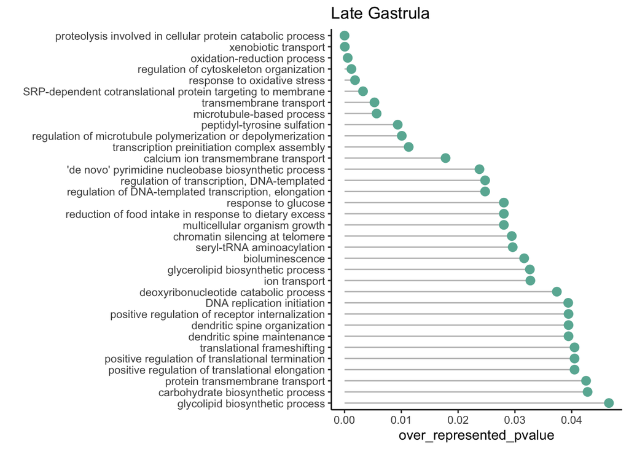

```r
LGGO.BP %>%
  mutate(term = fct_reorder(term, over_represented_pvalue, .desc = TRUE)) %>%
  ggplot(aes(x=term, y=over_represented_pvalue) ) +
      geom_segment( aes(x=term ,xend=term, y=0, yend=over_represented_pvalue), color="grey") +
      geom_point(size=3, color="#69b3a2") +
      coord_flip() +
      theme(
        panel.grid.minor.y = element_blank(),
        panel.grid.major.y = element_blank(),
        legend.position="none"
      ) +
  xlab("") +
  ylab("over_represented_pvalue") +
  ggtitle("Late Gastrula") + #add a main title
  theme(plot.title = element_text(face = 'bold',
                                  size = 12,
                                  hjust = 0)) +
  theme_bw() + #Set background color
  theme(panel.border = element_blank(), # Set border
                     panel.grid.major = element_blank(), #Set major gridlines
                     panel.grid.minor = element_blank(), #Set minor gridlines
                     axis.line = element_line(colour = "black"), #Set axes color
        plot.background=element_blank(),#Set the plot background
        legend.position="none")
```

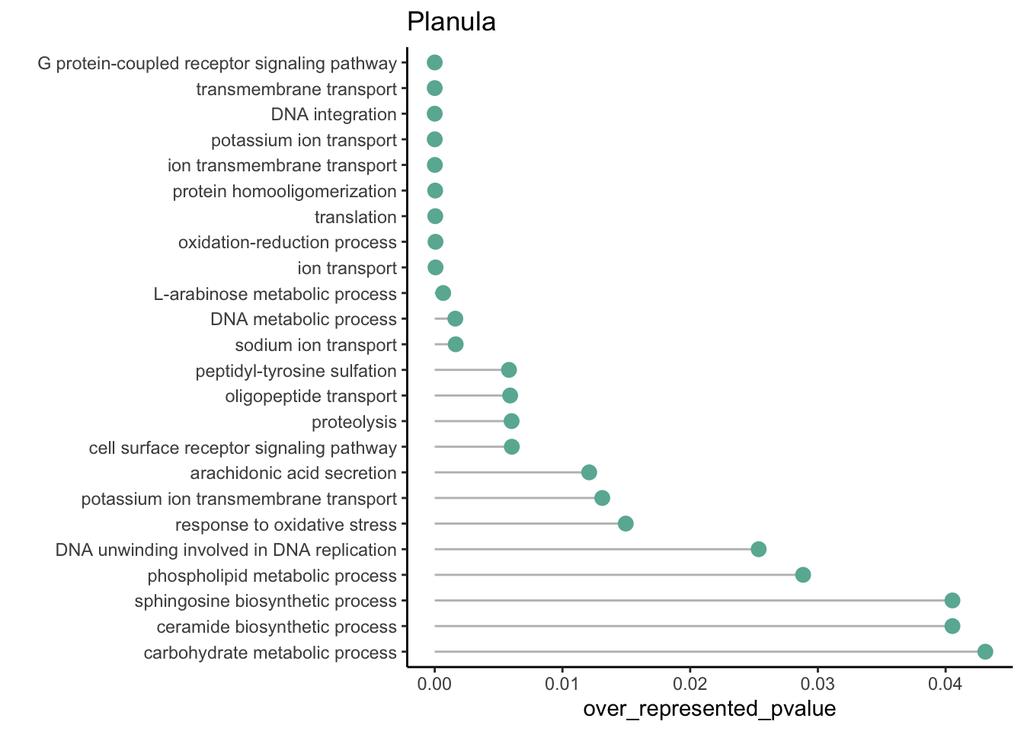

```r
PlnGO.BP %>%
  mutate(term = fct_reorder(term, over_represented_pvalue, .desc = TRUE)) %>%
  ggplot(aes(x=term, y=over_represented_pvalue) ) +
      geom_segment( aes(x=term ,xend=term, y=0, yend=over_represented_pvalue), color="grey") +
      geom_point(size=3, color="#69b3a2") +
      coord_flip() +
      theme(
        panel.grid.minor.y = element_blank(),
        panel.grid.major.y = element_blank(),
        legend.position="none"
      ) +
  xlab("") +
  ylab("over_represented_pvalue") +
  ggtitle("Planula") + #add a main title
  theme(plot.title = element_text(face = 'bold',
                                  size = 12,
                                  hjust = 0)) +
  theme_bw() + #Set background color
  theme(panel.border = element_blank(), # Set border
                     panel.grid.major = element_blank(), #Set major gridlines
                     panel.grid.minor = element_blank(), #Set minor gridlines
                     axis.line = element_line(colour = "black"), #Set axes color
        plot.background=element_blank(),#Set the plot background
        legend.position="none")
```

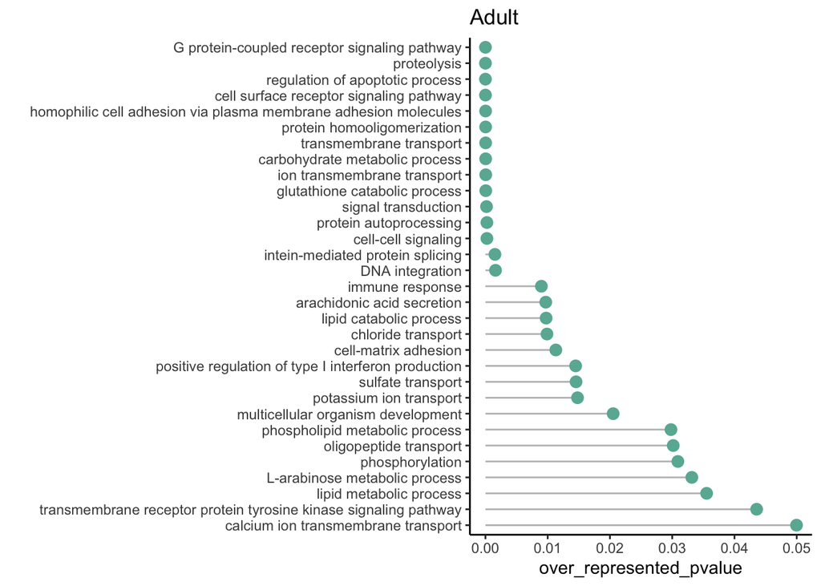

```r
AdultGO.BP %>%
  mutate(term = fct_reorder(term, over_represented_pvalue, .desc = TRUE)) %>%
  ggplot(aes(x=term, y=over_represented_pvalue) ) +
      geom_segment( aes(x=term ,xend=term, y=0, yend=over_represented_pvalue), color="grey") +
      geom_point(size=3, color="#69b3a2") +
      coord_flip() +
      theme(
        panel.grid.minor.y = element_blank(),
        panel.grid.major.y = element_blank(),
        legend.position="none"
      ) +
  xlab("") +
  ylab("over_represented_pvalue") +
  ggtitle("Adult") + #add a main title
  theme(plot.title = element_text(face = 'bold',
                                  size = 12,
                                  hjust = 0)) +
  theme_bw() + #Set background color
  theme(panel.border = element_blank(), # Set border
                     panel.grid.major = element_blank(), #Set major gridlines
                     panel.grid.minor = element_blank(), #Set minor gridlines
                     axis.line = element_line(colour = "black"), #Set axes color
        plot.background=element_blank(),#Set the plot background
        legend.position="none")
```

Save CSV of sig BP terms for each stage

```r
UEGO.BP$time_point <- c("Unfertilized_Egg")
FEGO.BP$time_point <- c("Fertilized_Egg")
ClvgGO.BP$time_point <- c("Cleavage")
PCGO.BP$time_point <- c("Prawn_chip")
EGGO.BP$time_point <- c("Early_gastrula")
MGGO.BP$time_point <- c("Mid_gastrula")
LGGO.BP$time_point <- c("Late_gastrula")
PlnGO.BP$time_point <- c("Planula")
AdultGO.BP$time_point <- c("Adult")
GO05.BP <- bind_rows(UEGO.BP, FEGO.BP, ClvgGO.BP, PCGO.BP, EGGO.BP, MGGO.BP, LGGO.BP, PlnGO.BP, AdultGO.BP)
GO05.BP <- GO05.BP[,c(8,6,1:5)]
write.csv(GO05.BP, "3-Semantic-Similarity/Output/stage_GO05_BP.csv", row.names = FALSE)

MatGO.BP$time_point <- c("Maternal")
ZGA1GO.BP$time_point <- c("ZGA1")
ZGA2GO.BP$time_point <- c("ZGA2")
AdultGO.BP$time_point <- c("Adult")
GO05.BP <- bind_rows(MatGO.BP, ZGA1GO.BP, ZGA2GO.BP, AdultGO.BP)
GO05.BP <- GO05.BP[,c(8,6,1:5)]
write.csv(GO05.BP, "3-Semantic-Similarity/Output/MZT_GO05_BP.csv", row.names = FALSE)

MatGO.MF$time_point <- c("Maternal")
ZGA1GO.MF$time_point <- c("ZGA1")
ZGA2GO.MF$time_point <- c("ZGA2")
AdultGO.MF$time_point <- c("Adult")
GO05.MF <- bind_rows(MatGO.MF, ZGA1GO.MF, ZGA2GO.MF, AdultGO.MF)
GO05.MF <- GO05.MF[,c(8,6,1:5)]
write.csv(GO05.MF, "3-Semantic-Similarity/Output/MZT_GO05_MF.csv", row.names = FALSE)
```